# Lab 8 - Unsupervised Learning

- Association Rules
- Clustering
  - *k*-Means
  - Hierarchical Clustering
- Summary

# Association Rules

Association rules is a popular and well-researched method for discovering interesting relationships between variables in large databases. The *arules* package in R provides a basic infrastructure for creating and manipulating input datasets for analyzing the resulting item sets and rules.

- For and introduction to *arules* and additional case studies, see [here](https://cran.r-project.org/web/packages/arules/vignettes/arules.pdf).
- For the reference manual for the package, see [here](https://cran.r-project.org/web/packages/arules/arules.pdf).

The *Groceries* dataset (included in the *arules* package) contains one month (30 days) of real-world point-of-sale transaction data from a typical local grocery outlet. The dataset contains 9,835 transactions, and the items are aggregated to 169 cateories.

```r
library(arules)
data("Groceries")

# run summary report
summary(Groceries)
```

```
## transactions as itemMatrix in sparse format with
##  9835 rows (elements/itemsets/transactions) and
##  169 columns (items) and a density of 0.02609146
##
## most frequent items:
##       whole milk other vegetables       rolls/buns             soda
##             2513             1903             1809             1715
##           yogurt          (Other)
##             1372            34055
##
## element (itemset/transaction) length distribution:
## sizes
##    1    2    3    4    5    6    7    8    9   10   11   12   13   14   15   16
## 2159 1643 1299 1005  855  645  545  438  350  246  182  117   78   77   55   46
##   17   18   19   20   21   22   23   24   26   27   28   29   32
##   29   14   14    9   11    4    6    1    1    1    1    3    1
##
##    Min. 1st Qu.  Median    Mean 3rd Qu.    Max.
##   1.000   2.000   3.000   4.409   6.000  32.000
##
## includes extended item information - examples:
##        labels  level2           level1
## 1 frankfurter sausage meat and sausage
## 2     sausage sausage meat and sausage
## 3  liver loaf sausage meat and sausage
```

To find the very long transactions, we can use the *size()* function and select very long transactions (containing more than 25 items).

```r
x <- Groceries[size(Groceries) > 25]
inspect(x)
```

```
##     items
## [1] {sausage,
##      finished products,
##      tropical fruit,
##      pip fruit,
##      other vegetables,
##      butter,
##      curd,
##      dessert,
##      butter milk,
##      yogurt,
##      whipped/sour cream,
##      soft cheese,
##      frozen vegetables,
##      rolls/buns,
##      white bread,
##      brown bread,
##      pastry,
##      pasta,
##      soups,
##      baby food,
##      fruit/vegetable juice,
##      salty snack,
##      waffles,
##      cake bar,
##      chocolate,
##      shopping bags}
## [2] {frankfurter,
##      sausage,
##      liver loaf,
##      ham,
##      chicken,
##      beef,
##      citrus fruit,
##      tropical fruit,
##      root vegetables,
##      other vegetables,
##      whole milk,
##      butter,
##      curd,
```

[output cut: 146 more lines]

```
##      frozen fish,
##      frozen potato products,
##      brown bread,
##      margarine,
##      baking powder,
##      cat food,
##      pet care,
##      soda,
##      fruit/vegetable juice,
##      nut snack,
##      chocolate,
##      female sanitary products,
##      hygiene articles,
##      napkins,
##      house keeping products}
```

To see which items are important in the dataset, we can use the *itemFrequencyPlot()* function. To reduce the number of items, we only plot the item frequency for items with support of at least 10%. The label size is reduced with the parameter *cex.names*.

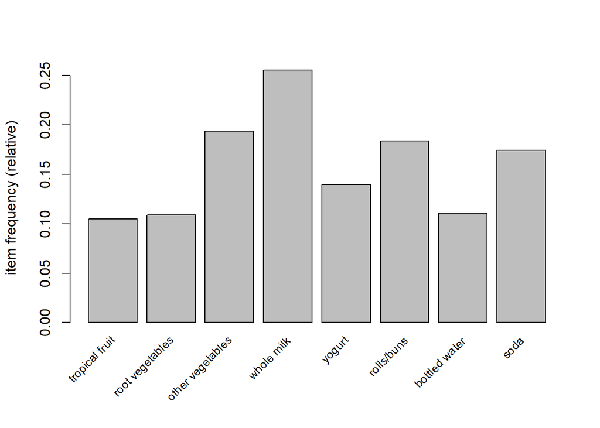

```r
itemFrequencyPlot(Groceries, support = 0.1, cex.names = 0.8)
```

Use the *apriori* algorithm to find all rules (the default association type for *apriori()*) with a minimum support of 0.3% and a confidence of 0.5.

```r
# run the apriori algorithm
basket_rules <- apriori(Groceries, parameter = list(sup = 0.003, conf = 0.5, target = "rules"))
```

```
## Apriori
##
## Parameter specification:
##  confidence minval smax arem  aval originalSupport maxtime support minlen
##         0.5    0.1    1 none FALSE            TRUE       5   0.003      1
##  maxlen target   ext
##      10  rules FALSE
##
## Algorithmic control:
##  filter tree heap memopt load sort verbose
##     0.1 TRUE TRUE  FALSE TRUE    2    TRUE
##
## Absolute minimum support count: 29
##
## set item appearances ...[0 item(s)] done [0.00s].
## set transactions ...[169 item(s), 9835 transaction(s)] done [0.01s].
## sorting and recoding items ... [136 item(s)] done [0.00s].
## creating transaction tree ... done [0.00s].
## checking subsets of size 1 2 3 4 5 done [0.00s].
## writing ... [421 rule(s)] done [0.00s].
## creating S4 object  ... done [0.00s].
```

```r
summary(basket_rules)
```

```
## set of 421 rules
##
## rule length distribution (lhs + rhs):sizes
##   2   3   4   5
##   5 281 128   7
##
##    Min. 1st Qu.  Median    Mean 3rd Qu.    Max.
##   2.000   3.000   3.000   3.325   4.000   5.000
##
## summary of quality measures:
##     support           confidence          lift           count
##  Min.   :0.003050   Min.   :0.5000   Min.   :1.957   Min.   : 30.00
##  1st Qu.:0.003355   1st Qu.:0.5238   1st Qu.:2.135   1st Qu.: 33.00
##  Median :0.003965   Median :0.5556   Median :2.426   Median : 39.00
##  Mean   :0.004754   Mean   :0.5715   Mean   :2.522   Mean   : 46.75
##  3rd Qu.:0.005186   3rd Qu.:0.6094   3rd Qu.:2.766   3rd Qu.: 51.00
##  Max.   :0.022267   Max.   :0.8857   Max.   :5.804   Max.   :219.00
##
## mining info:
##       data ntransactions support confidence
##  Groceries          9835   0.003        0.5
```

Recall from class:

- **Support**: The support of an item set *X* is defined as the proportion of transactions in the dataset which contain the item set. In the Groceries data, the support for the rules is relatively low, with a maximum support of less than 3%.
- **Confidence**: The confidence of a rule $X \implies Y$ (“If X, then Y”) is defined as $conf(X \implies Y) = supp(X \cup Y) / supp(X)$. For example, if the rule ${milk, bread} \implies {butter}$ has a confidence of 0.5, this means that for 50% of the transactions containing milk and bread, the rule is correct. Confidence can be interpreted as an estimate of the conditional probability $P(Y | X)$, the probability of finding the consequent (RHS) of the rule in transactions under the condition that the transactions also contain the antecedent (LHS). Association rules are also required to satisfy both a minimum support and a minimum confidence constraint simultaneously.
- **Lift**: Lift is a popular measure to filter or rank found rules. The lift of a rule $X \implies Y$ is defined as $lift(X \implies Y) = supp(X \cup Y) / (supp(X)supp(Y))$. Lift can be interpreted as the deviation of the support of the whole rule from the support expected under independence given the supports of the antecedent and consequent. Greater lift values indicate stronger associations.

```r
# check the generated rules using inspect()
inspect(head(sort(basket_rules, by = "lift")))
```

```
##     lhs                   rhs                    support confidence     lift count
## [1] {citrus fruit,
##      tropical fruit,
##      other vegetables,
##      whole milk}       => {root vegetables}  0.003152008  0.6326531 5.804238    31
## [2] {citrus fruit,
##      root vegetables,
##      other vegetables,
##      whole milk}       => {tropical fruit}   0.003152008  0.5438596 5.183004    31
## [3] {herbs,
##      whole milk}       => {root vegetables}  0.004168785  0.5394737 4.949369    41
## [4] {herbs,
##      other vegetables} => {root vegetables}  0.003863752  0.5000000 4.587220    38
## [5] {citrus fruit,
##      tropical fruit,
##      root vegetables,
##      whole milk}       => {other vegetables} 0.003152008  0.8857143 4.577509    31
## [6] {tropical fruit,
##      whole milk,
##      curd}             => {yogurt}           0.003965430  0.6093750 4.368224    39
```

As is typical for association rules mining, the number of rules found is huge. To analyze these rules, for example, *subset()* can be used to produce separate subsets of rules. Now find the subset of rules that has length of more than 4 (LHS + RHS).

```r
# basket rules of size greater than 4
inspect(subset(basket_rules, size(basket_rules) > 4))
```

```
##     lhs                   rhs                    support confidence     lift count
## [1] {citrus fruit,
##      tropical fruit,
##      root vegetables,
##      other vegetables} => {whole milk}       0.003152008  0.7045455 2.757344    31
## [2] {citrus fruit,
##      tropical fruit,
##      root vegetables,
##      whole milk}       => {other vegetables} 0.003152008  0.8857143 4.577509    31
## [3] {citrus fruit,
##      tropical fruit,
##      other vegetables,
##      whole milk}       => {root vegetables}  0.003152008  0.6326531 5.804238    31
## [4] {citrus fruit,
##      root vegetables,
##      other vegetables,
##      whole milk}       => {tropical fruit}   0.003152008  0.5438596 5.183004    31
## [5] {tropical fruit,
##      root vegetables,
##      other vegetables,
##      yogurt}           => {whole milk}       0.003558719  0.7142857 2.795464    35
## [6] {tropical fruit,
##      root vegetables,
##      whole milk,
##      yogurt}           => {other vegetables} 0.003558719  0.6250000 3.230097    35
## [7] {tropical fruit,
##      root vegetables,
##      other vegetables,
##      whole milk}       => {yogurt}           0.003558719  0.5072464 3.636128    35
```

Find the subset of rules with lift greater than 5.

```r
inspect(subset(basket_rules, lift > 5))
```

```
##     lhs                   rhs                   support confidence     lift count
## [1] {citrus fruit,
##      tropical fruit,
##      other vegetables,
##      whole milk}       => {root vegetables} 0.003152008  0.6326531 5.804238    31
## [2] {citrus fruit,
##      root vegetables,
##      other vegetables,
##      whole milk}       => {tropical fruit}  0.003152008  0.5438596 5.183004    31
```

Now find the subset of rules that has yogurt in the consequent. Here we require lift to be greater than 3.

```r
yogurt.rhs <- subset(basket_rules, subset = rhs %in% "yogurt" & lift > 3)
```

Now inspect the subset of rules.

```r
inspect(yogurt.rhs)
```

```
##     lhs                     rhs          support confidence     lift count
## [1] {whipped/sour cream,
##      cream cheese }      => {yogurt} 0.003355363  0.5238095 3.754859    33
## [2] {root vegetables,
##      cream cheese }      => {yogurt} 0.003762074  0.5000000 3.584184    37
## [3] {tropical fruit,
##      curd}               => {yogurt} 0.005287239  0.5148515 3.690645    52
## [4] {other vegetables,
##      whole milk,
##      cream cheese }      => {yogurt} 0.003457041  0.5151515 3.692795    34
## [5] {tropical fruit,
##      whole milk,
##      curd}               => {yogurt} 0.003965430  0.6093750 4.368224    39
## [6] {tropical fruit,
##      other vegetables,
##      butter}             => {yogurt} 0.003050330  0.5555556 3.982426    30
## [7] {tropical fruit,
##      whole milk,
##      butter}             => {yogurt} 0.003355363  0.5409836 3.877969    33
## [8] {tropical fruit,
##      whole milk,
##      whipped/sour cream} => {yogurt} 0.004372140  0.5512821 3.951792    43
## [9] {tropical fruit,
##      root vegetables,
##      other vegetables,
##      whole milk}         => {yogurt} 0.003558719  0.5072464 3.636128    35
```

Now find the subset of rules that have meat in the antecedent.

```r
meat.lhs <- subset(basket_rules, subset = lhs %in% "meat" & lift > 1.5)
```

Now inspect the subset of rules.

```r
inspect(meat.lhs)
```

```
##     lhs                       rhs          support     confidence lift
## [1] {meat,root vegetables} => {whole milk} 0.003152008 0.62       2.426462
##     count
## [1] 31
```

# Clustering

We will use the *seeds_dataset* to demonstrate cluster analysis in R. The examined group comprised kernels belonging to three different varieties of wheat: Kama, Rosa, and Canadian, 70 elements each. A description of the dataset can be viewed [here](https://archive.ics.uci.edu/ml/datasets/seeds).

```r
seed <- read.table("seeds_dataset.txt")
seed <- seed[, 1:7]
colnames(seed) <- c("area", "perimeter", "compactness", "length", "width", "asymmetry", "groovelength")
```

Scale data to z-scores with zero mean and unit variance for each column. (You could also use the *preProcess()* function as we have done previously.)

```r
seed <- scale(seed)
```

## *k*-Means

Use the *k*-means method for clustering and plot the results. We’ll start by looking at *k*=5 clusters

```r
# k-means cluster analysis
set.seed(1)
fit <- kmeans(seed, 5) # 5 cluster solution

# display the number of kernels in each cluster
table(fit$cluster)
```

```
##
##  1  2  3  4  5
## 45 18 56 51 40
```

Plot the clusters.

```r
install.packages("fpc")
```

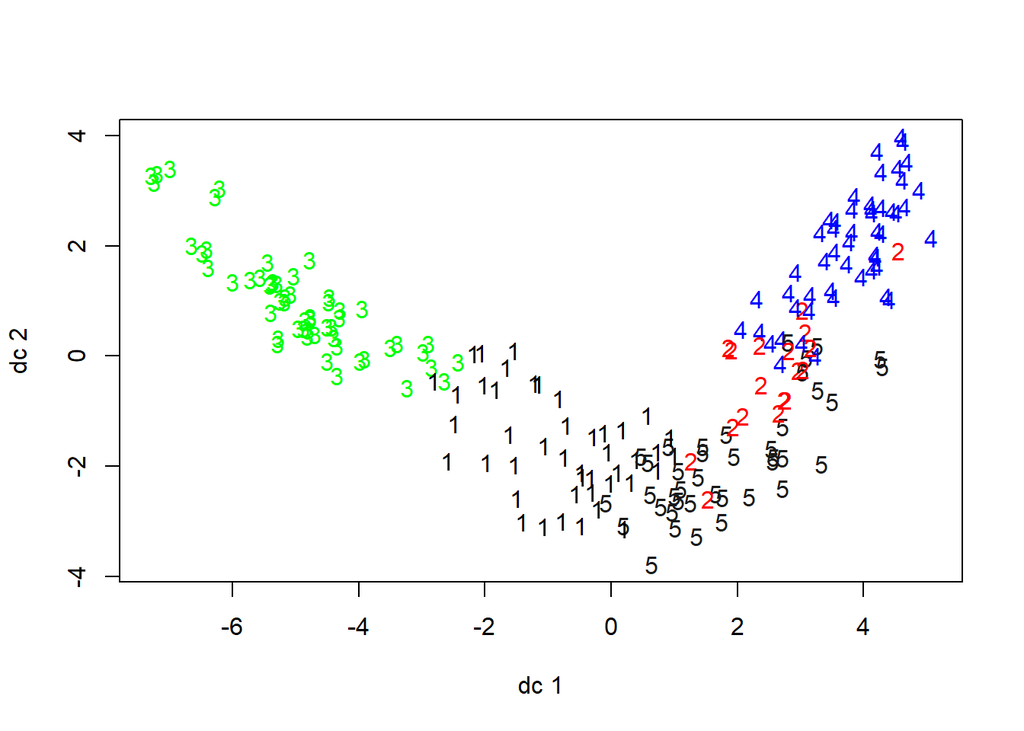

```r
library(fpc)
plotcluster(seed, fit$cluster)
```

In this plot, the axes represent the first two discriminant coordinates, which are uncorrelated linear functions of the variables that best separate the categories. With 5 clusters here, there is not necessarily clear separation of the clusters.

We can see exactly which items are in the first cluster.

```r
seed[fit$cluster == 1, ]
```

[output not shown]

We can also get the center of each group.

```r
fit$centers
```

```
##         area  perimeter compactness     length      width  asymmetry
## 1  0.2466954  0.2704211   0.3439821  0.2325225  0.3085097 -0.3995553
## 2 -0.6788679 -0.7383738   0.1510023 -0.7962992 -0.4877120  1.4076390
## 3  1.3885128  1.3867754   0.5989659  1.3721886  1.2746370 -0.0910015
## 4 -1.1092967 -1.0549469  -1.3160126 -0.8935647 -1.2531431  0.6425384
## 5 -0.5016064 -0.5683837   0.3844330 -0.6850222 -0.3143374 -0.8757721
##   groovelength
## 1   0.04190449
## 2  -0.68322884
## 3   1.39643675
## 4  -0.55553010
## 5  -0.98640013
```

```r
# it is the equivalent of using the aggregate() function
aggregate(seed, by = list(fit$cluster), FUN = mean)
```

```
##   Group.1       area  perimeter compactness     length      width  asymmetry
## 1       1  0.2466954  0.2704211   0.3439821  0.2325225  0.3085097 -0.3995553
## 2       2 -0.6788679 -0.7383738   0.1510023 -0.7962992 -0.4877120  1.4076390
## 3       3  1.3885128  1.3867754   0.5989659  1.3721886  1.2746370 -0.0910015
## 4       4 -1.1092967 -1.0549469  -1.3160126 -0.8935647 -1.2531431  0.6425384
## 5       5 -0.5016064 -0.5683837   0.3844330 -0.6850222 -0.3143374 -0.8757721
##   groovelength
## 1   0.04190449
## 2  -0.68322884
## 3   1.39643675
## 4  -0.55553010
## 5  -0.98640013
```

We can see that the clusters can be defined by the following characteristics:

- Cluster 1: relatively close to average for all predictors
- Cluster 2: large asymmetry
- Cluster 3: large area, perimeter, length, width, and groove length
- Cluster 4: small area, perimeter, compactness, and width
- Cluster 5: relatively small groove length

Let’s see if we can determine a number of clusters that shows better distinction among clusters.

### Determine the Number of Clusters

Here, a simple within-group sum of squares method (wss) is used to determine the appropriate number of clusters. We can calculate the wss for different numbers of clusters.

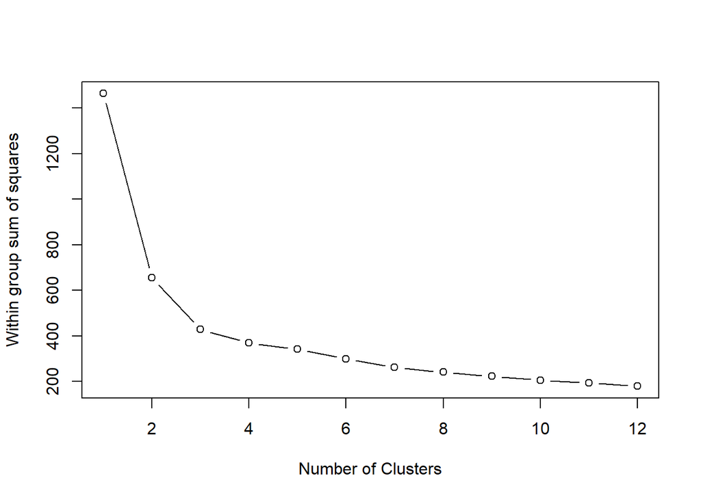

```r
wss <- rep(0, 12)
for (i in 1:12) {
  wss[i] <- sum(kmeans(seed, centers = i)$withinss)
}
plot(1:12, wss, type = "b", xlab = "Number of Clusters", ylab = "Within group sum of squares")
```

One method for choosing the optimal number of clusters is called “the elbow method”. If the line chart looks like an arm, then the “elbow” on the arm is the value of *k* that is the best. The idea is that we want a small SSE, but that the SSE tends to decrease toward 0 as we increase *k* (the SSE is 0 when *k* is equal to the number of data points in the dataset, because then each data point is its own cluster, and there is no error between it and the center of its cluster). So our goal is to choose a small value of *k* that still has a low SSE, and the elbow usually represents where we start to have diminishing returns by increasing *k*.

In this example, it appears that three clusters would be ideal. Let’s try *k*-means again but with three clusters.

```r
set.seed(1)
fit1 <- kmeans(seed, 3) # 3 cluster solution

# display the number of kernels in each cluster
table(fit1$cluster)
```

```
##
##  1  2  3
## 71 72 67
```

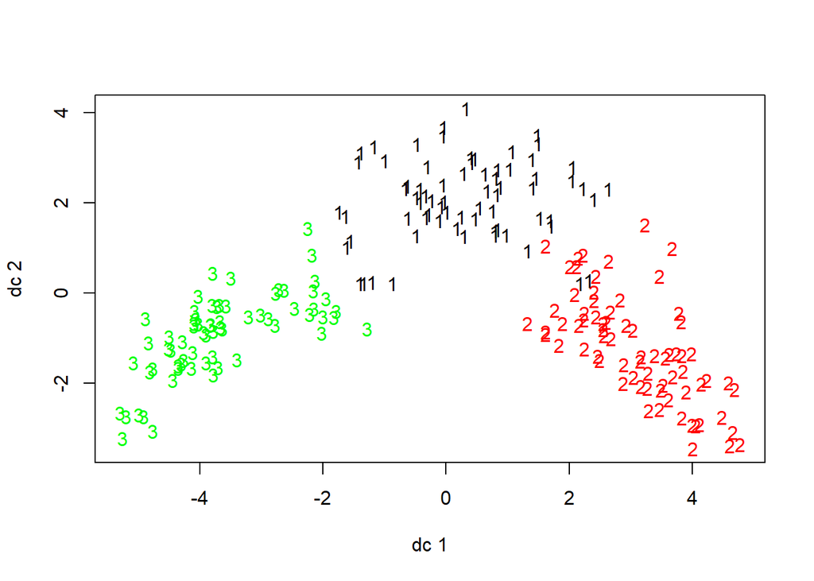

```r
plotcluster(seed, fit1$cluster)
```

```r
fit1$centers
```

```
##         area  perimeter compactness     length        width   asymmetry
## 1 -0.1407831 -0.1696372   0.4485346 -0.2571999  0.001643014 -0.66034079
## 2 -1.0277967 -1.0042491  -0.9626050 -0.8955451 -1.082995635  0.69314821
## 3  1.2536860  1.2589580   0.5591283  1.2349319  1.162075101 -0.04511157
##   groovelength
## 1   -0.5844965
## 2   -0.6233191
## 3    1.2892273
```

Here we see that the three clusters have the following characteristics:

- Cluster 1: relatively close to average in all variables
- Cluster 2: small area, perimeter, and width; relatively small compactness
- Cluster 3: large area, perimeter, length, width, and groove length

## Hierarchical Clustering

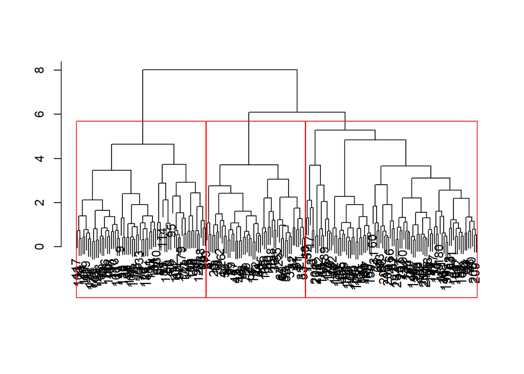

```r
# calculate the distance matrix
seed.dist <- dist(seed)

# obtain clusters
seed.hclust <- hclust(seed.dist)
plot(seed.hclust, ann = FALSE)

# cut dendrogram at the three clusters level and obtain cluster membership
seed.3clust <- cutree(seed.hclust, k=3)
rect.hclust(seed.hclust, k=3)
```

We can see exactly which items are in the third group.

```r
seed[seed.3clust == 3, ]
```

[output not shown]

Again, we can calculate the centroid of each group.

```r
aggregate(seed, by = list(seed.3clust), FUN = mean)
```

```
##   Group.1        area    perimeter compactness     length      width
## 1       1  0.01545733 -0.002398137   0.4911367 -0.0887064  0.1601511
## 2       2  1.21893721  1.233132514   0.4950193  1.2277398  1.1138930
## 3       3 -0.92990568 -0.930314532  -0.6577825 -0.8763730 -0.9341398
##     asymmetry groovelength
## 1 -0.81490533   -0.4377948
## 2 -0.03217531    1.2820550
## 3  0.49514443   -0.7157157
```

How are these three clusters characterized?

Draw the clusters on a two-dimensional graph.

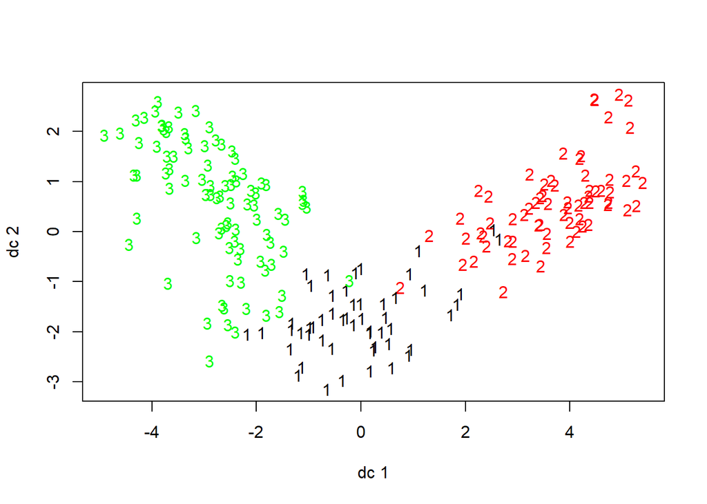

```r
library(fpc)
plotcluster(seed, seed.3clust)
```

# Summary

- Association rules are useful for determining “what goes with what” - can be great tools for creating sales promotions, identifying comorbidities in healthcare, etc.
- Ideally, you want to find rules with high support, confidence, and lift.
- Clustering is an exploratory task for finding groups of similar records.
- It is critical that your clusters are meaningful and not just randomly assigned.
- Upon finding useful clusters, cluster membership can become a predictor in any supervised learning task you attempt.